# Spaceship Titanic

# Introduction

# Tidying

Libraries in use.

```r
library(tidyr)
library(dplyr)
```

Getting the data and checking out its content. We can begin by changing each column to the correct type. There are also some missing values within each category to consider.

```r
data <- read.csv("train.csv", na.strings = c("", NA, "NA"))
str(data)
```

```
## 'data.frame':    8693 obs. of  14 variables:
##  $ PassengerId : chr  "0001_01" "0002_01" "0003_01" "0003_02" ...
##  $ HomePlanet  : chr  "Europa" "Earth" "Europa" "Europa" ...
##  $ CryoSleep   : chr  "False" "False" "False" "False" ...
##  $ Cabin       : chr  "B/0/P" "F/0/S" "A/0/S" "A/0/S" ...
##  $ Destination : chr  "TRAPPIST-1e" "TRAPPIST-1e" "TRAPPIST-1e" "TRAPPIST-1e" ...
##  $ Age         : num  39 24 58 33 16 44 26 28 35 14 ...
##  $ VIP         : chr  "False" "False" "True" "False" ...
##  $ RoomService : num  0 109 43 0 303 0 42 0 0 0 ...
##  $ FoodCourt   : num  0 9 3576 1283 70 ...
##  $ ShoppingMall: num  0 25 0 371 151 0 3 0 17 0 ...
##  $ Spa         : num  0 549 6715 3329 565 ...
##  $ VRDeck      : num  0 44 49 193 2 0 0 NA 0 0 ...
##  $ Name        : chr  "Maham Ofracculy" "Juanna Vines" "Altark Susent" "Solam Susent" ...
##  $ Transported : chr  "False" "True" "False" "False" ...
```

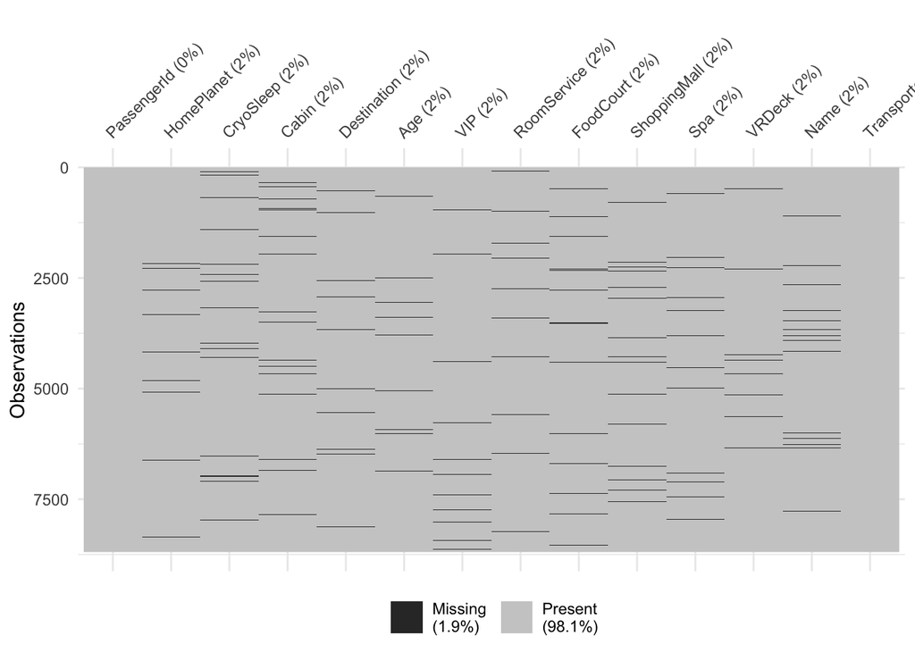

```r
naniar::vis_miss(data)
```

## Correcting data types

For `PassengerId`, we know that it “indicates a group the passenger is travelling with and … their number within the group”. There might be a correlation between being transported and the sized of the group. Furthermore, we shall use the groups to calculate any missing values. Hence, we shall extract the group number and group size and use it as a factor respectively numerical value.

```r
len <- unique(sapply(data$PassengerId, nchar))
groupId <- sapply(data$PassengerId, substr, 1, 4, USE.NAMES = F)
groupSize <-
  sapply(data$PassengerId, substr, len - 1, len, USE.NAMES = F)

data <- data %>%
  mutate(groupId = as.factor(groupId),
         groupSize = as.numeric(groupSize)) %>%
  group_by(groupId) %>%
  mutate(groupSize = max(groupSize, na.rm = TRUE))
```

`HomePlanet`, `CryoSleep`, `Destination`, `VIP`, and `Transported` simply needs to be factorized.

```r
data <- data %>%
    mutate(across(
        c(HomePlanet, CryoSleep, Destination, VIP, Transported),
        as.factor
        ))
```

We shall separate the cabin into three columns and categorize them. It also seems likely that there should be synergy between these categories we need to consider later on.

```r
data <- data %>%
  separate(Cabin, into = c("deck", "num", "side"), sep = "/") %>%
  mutate(across(c("deck", "num", "side"), as.factor))
```

## Missing values

```r
getMode <- function(x) {
  ux <- na.omit(x)
  names(sort(table(ux), decreasing = TRUE))[1]
}

modes <- data %>%
  mutate(groupSizeCategory = ifelse(groupSize > 1, "multiple", "single")) %>%
  group_by(groupId, groupSizeCategory) %>%
  transmute(
    groupId = groupId,
    modePlaner = getMode(HomePlanet),
    modeSleep = getMode(CryoSleep),
    modeDeck = getMode(deck),
    modeNum = getMode(num),
    modeSide = getMode(side),
    modeDest = getMode(Destination),
    modeVIP = getMode(VIP)
  ) %>%
  unique() %>%
  ungroup() %>%
  arrange(groupId) %>%
  mutate(across(everything(), as.factor))

data <- data %>%
  left_join(modes, by = "groupId") %>%
  mutate(
    HomePlanet = coalesce(HomePlanet, modePlaner),
    CryoSleep = coalesce(CryoSleep, modeSleep),
    deck = coalesce(deck, modeDeck),
    num = coalesce(num, modeNum),
    side = coalesce(side, modeSide),
    Destination = coalesce(Destination, modeDest),
    VIP = coalesce(VIP, modeVIP)
  )
```

For numerical values we use the same method as above, but use the average instead.

```r
averages <- data %>%
  mutate(groupSizeCategory = ifelse(groupSize > 1, "multiple", "single")) %>%
  group_by(groupId, groupSizeCategory) %>%
  transmute(
    avgAge = mean(Age, na.rm = T),
    avgRoomService = mean(RoomService, na.rm = T),
    avgFoodCourt = mean(FoodCourt, na.rm = T),
    avgShoppingMall = mean(ShoppingMall, na.rm = T),
    avgSpa = mean(Spa, na.rm = T),
    avgVRDeck = mean(VRDeck, na.rm = T)
  ) %>%
  unique() %>%
  ungroup() %>%
  arrange(groupId)

data <- data %>%
  left_join(averages, by = "groupId") %>%
  mutate(
    Age = coalesce(Age, avgAge),
    RoomService = coalesce(RoomService, avgRoomService),
    FoodCourt = coalesce(FoodCourt, avgFoodCourt),
    ShoppingMall = coalesce(ShoppingMall, avgShoppingMall),
    Spa = coalesce(Spa, avgSpa),
    VRDeck = coalesce(VRDeck, avgVRDeck)
  ) %>%
  ungroup(groupId) %>%
  na.omit()
```

A final cleanup:

- Too many `num`
- No need for the mode/average cols
- Remove Name, Id

```r
summary(data)
```

```
##  PassengerId         HomePlanet   CryoSleep         deck           num
##  Length:7892        Europa:2125   False:5082   F      :2505   0      : 107
##  Class :character   Earth :4136   True :2810   G      :2323   82     :  28
##  Mode  :character   Mars  :1631                B      : 850   97     :  21
##                                                E      : 806   86     :  21
##                                                C      : 712   19     :  20
##                                                D      : 444   56     :  20
##                                                (Other): 252   (Other):7675
##  side            Destination        Age           VIP        RoomService
##  P:3938   TRAPPIST-1e  :5511   Min.   : 0.00   False:7705   Min.   :    0.0
##  S:3954   PSO J318.5-22: 719   1st Qu.:19.00   True : 187   1st Qu.:    0.0
##           55 Cancri e  :1662   Median :27.00                Median :    0.0
##                                Mean   :28.72                Mean   :  224.2
##                                3rd Qu.:38.00                3rd Qu.:   46.0
##                                Max.   :79.00                Max.   :14327.0
##
##    FoodCourt        ShoppingMall          Spa            VRDeck
##  Min.   :    0.0   Min.   :    0.0   Min.   :    0   Min.   :    0.0
##  1st Qu.:    0.0   1st Qu.:    0.0   1st Qu.:    0   1st Qu.:    0.0
##  Median :    0.0   Median :    0.0   Median :    0   Median :    0.0
##  Mean   :  469.2   Mean   :  169.4   Mean   :  318   Mean   :  304.4
##  3rd Qu.:   79.0   3rd Qu.:   23.0   3rd Qu.:   62   3rd Qu.:   46.0
##  Max.   :29813.0   Max.   :12253.0   Max.   :22408   Max.   :20336.0
##
##      Name           Transported     groupId       groupSize
##  Length:7892        False:3881   4256   :   8   Min.   :1.000
##  Class :character   True :4011   4498   :   8   1st Qu.:1.000
##  Mode  :character                5885   :   8   Median :1.000
##                                  8168   :   8   Mean   :2.111
##                                  8728   :   8   3rd Qu.:3.000
##                                  8796   :   8   Max.   :8.000
##                                  (Other):7844
##  groupSizeCategory.x  modePlaner   modeSleep       modeDeck       modeNum
##  multiple:3788       Earth :4136   False:5635   F      :2703   0      : 109
##  single  :4104       Europa:2125   True :2257   G      :2320   82     :  29
##                      Mars  :1631                B      : 856   19     :  21
##                                                 C      : 708   86     :  21
##                                                 E      : 674   97     :  21
##                                                 D      : 381   230    :  20
##                                                 (Other): 250   (Other):7671
```

[output cut: 9 more lines]

```
##  Min.   :   0.0   Min.   :    0.0   Min.   :    0.0   Min.   :    0.0
##  1st Qu.:   0.0   1st Qu.:    0.0   1st Qu.:    0.0   1st Qu.:    0.0
##  Median :   0.0   Median :    0.5   Median :    0.0   Median :    1.0
##  Mean   : 224.3   Mean   :  469.1   Mean   :  170.9   Mean   :  318.0
##  3rd Qu.: 179.1   3rd Qu.:  289.5   3rd Qu.:  117.1   3rd Qu.:  207.2
##  Max.   :9920.0   Max.   :26830.0   Max.   :10705.0   Max.   :22408.0
##
##    avgVRDeck
##  Min.   :    0.0
##  1st Qu.:    0.0
##  Median :    0.0
##  Mean   :  307.3
##  3rd Qu.:  187.2
##  Max.   :17074.0
##
```

```r
data <- data %>%
  select(
    HomePlanet,
    CryoSleep,
    deck,
    side,
    Destination,
    Age,
    VIP,
    RoomService,
    FoodCourt,
    ShoppingMall,
    Spa,
    VRDeck,
    Transported,
    groupSize
  )
```

# Modeling

Below we find the correlatio between being transported and the other variables.

```r
matr <- model.matrix(~0+., data=data) %>%
  cor(use="pairwise.complete.obs")
vec <- matr[,22]
sort(abs(vec), decr = T)
```

```
##          TransportedTrue            CryoSleepTrue              RoomService
##              1.000000000              0.456727239              0.242532054
##                      Spa                   VRDeck         HomePlanetEuropa
##              0.221339443              0.209612452              0.176559174
##          HomePlanetEarth   Destination55 Cancri e                    deckC
##              0.168522855              0.119545861              0.110705296
##                    sideS                    deckE                    deckF
##              0.108699265              0.098462265              0.085016364
##                groupSize                      Age                FoodCourt
##              0.082330348              0.080260565              0.049881442
##                  VIPTrue                    deckD           HomePlanetMars
##              0.045059999              0.040321154              0.014438664
##                    deckG                    deckT             ShoppingMall
##              0.010770740              0.006822373              0.003993598
##                    deckA DestinationPSO J318.5-22
##              0.002101272              0.001252329
```

By a backward substitution fitting, we’ve discovered the following significant predictors. We also implement a LDA and KNN to test if it performs better than logistic regression. We observe the logistic regression to perform the best.

```r
train <- sample(c(TRUE, FALSE), nrow(data), TRUE)
model <-
  glm(
    Transported ~ HomePlanet + CryoSleep + deck + side + Destination + Age + RoomService + FoodCourt + ShoppingMall + Spa + VRDeck,
    data = data,
    family = binomial,
    subset = train
  )
model2 <-
  MASS::lda(
    Transported ~ HomePlanet + CryoSleep + deck + side + Destination + Age + RoomService + FoodCourt + ShoppingMall + Spa + VRDeck,
    data = data,
    subset = train
  )

knn_data <- data %>%
  select(Age, RoomService, FoodCourt, ShoppingMall, Spa, VRDeck)

model3 <-
  class::knn(
    train = knn_data[train,],
    test = knn_data[!train,],
    cl = data$Transported[train],
    k = 1
  )



probs <- predict(model, newdata = data[!train, ], type = "response")
probs2 <-
  predict(model2, newdata = data[!train, ], type = "response")
preds <- ifelse(probs > .5, "True", "False")

mean(preds == data[!train, ]$Transported)
```

```
## [1] 0.7901391
```

```r
mean(probs2$class == data[!train, ]$Transported)
```

```
## [1] 0.7701643
```

```r
mean(model3 == data[!train, ]$Transported)
```

```
## [1] 0.7514539
```

# Prediction

We shall now use the model to predict the transporation.

```r
testFull <- read.csv("test.csv", na.strings = c("", NA, "NA"))
test <- testFull %>%
  select(
    HomePlanet,
    CryoSleep,
    Cabin,
    Destination,
    Age,
    RoomService,
    FoodCourt,
    ShoppingMall,
    Spa,
    VRDeck
  ) %>%
  separate(Cabin, into = c("deck", "num", "side"), sep = "/") %>%
  mutate(across(
    c(HomePlanet, CryoSleep, Destination, "deck", "num", "side"),
    as.factor
  )) %>%
  select(-num)
```

We have to impute NAs in the test data as well.

```r
test <- multiUS::KNNimp(test)
```

Prediction

```r
preds <- predict(model, test, type = "response")
submission <- testFull %>%
  select(PassengerId) %>%
  mutate(Transported = ifelse(preds < 0.5, "False", "True"))

write.csv(submission, "submission.csv", row.names = F)
```